# Ask Mattrab Note-Views Analysis

Author

Rabin Kumar Kalikote

Published

April 3, 2025

# 1 Introduction

## 1.1 Data: Ask Mattrab Note Views

The dataset used in this analysis was extracted from the database of the educational platform [Ask Mattrab](https://www.askmattrab.com). Ask Mattrab is a collaborative learning platform where users can create, share, and access educational notes. The platform allows users to publish notes on various subjects and grades, making it a valuable resource for students and educators.

### 1.1.1 Dataset Description

- **id**: Primary key, a unique identifier for each note.
- **title**: The title of the note, which users see before opening the note.
- **body**: The number of characters in the content of the note. (The actual content is excluded for privacy and security reasons.)
- **created_at**: The date when the note was created.
- **updated_at**: The date when the note was last modified.
- **user_id**: The ID of the user who created the note (foreign key).
- **image_file_name**: The name of the thumbnail image associated with the note.
- **image_content_type**: The type of the thumbnail image (e.g., JPEG, PNG).
- **image_file_size**: The size of the thumbnail image in bytes.
- **image_updated_at**: The date when the thumbnail image was last updated.
- **view**: The total number of times the note was opened and read (target variable).
- **is_verified**: A boolean indicating whether the note is verified for publication.
- **status**: The publication status of the note (e.g., draft or published).
- **grade_id**: The grade level (foreign key) to which the note belongs.
- **subject_id**: The subject (foreign key) to which the note belongs.
- **chapter_id**: The chapter (foreign key) to which the note belongs.
- **position**: Indicates whether the note is visible in the Ask Mattrab library.

### 1.1.2 Objective

The primary goal of this analysis is to build a predictive model to estimate the number of views (`view`) a note will receive based on its features. This can help content creators and platform administrators optimize their strategies for creating and promoting educational content.

### 1.1.3 Data Source

The dataset was extracted directly from the Ask Mattrab database. It represents real-world user interactions and content metadata, making it a rich source for analysis and modeling.

# 2 Loading & Cleaning the Data

The data are contained in notes_export.csv. Load the data.

```r
notes <- read_csv("notes_export.csv")

glimpse(notes)
```

```
Rows: 1,504
Columns: 26
$ id                   <dbl> 1, 7, 8, 12, 16, 17, 18, 25, 28, 29, 31, 32, 33, …
$ title                <chr> "What is thermocouple effect?", "What is Energy C…
$ body                 <dbl> 6472, 1168, 3454, 5658, 1699, 3414, 1707, 3342, 2…
$ created_at           <chr> "2020-03-09 06:33:29 UTC", "2020-02-27 06:50:21 U…
$ updated_at           <chr> "2025-03-21 20:35:10 UTC", "2025-03-22 03:09:39 U…
$ user_id              <dbl> 1, 6, 6, 25, 37, 37, 46, 115, 38, 14, 38, 14, 38,…
$ image_file_name      <chr> "thermocouple.png", "t.jpeg", "binding_energy.png…
$ image_content_type   <chr> "image/png", "image/jpeg", "image/png", "image/jp…
$ image_file_size      <dbl> 30547, 9272, 37627, 11906, 3664, 5609, 51857, 957…
$ image_updated_at     <chr> "2020-03-09 07:18:49 UTC", "2020-06-05 10:48:56 U…
$ view                 <dbl> 2540, 1516, 1509, 1837, 1433, 4564, 2371, 2527, 1…
$ ecategory            <dbl> 0, 0, 0, 0, 0, 0, 5, 1, 1, 1, 1, 1, 0, 5, 5, 5, 5…
$ is_verified          <lgl> TRUE, TRUE, TRUE, TRUE, TRUE, TRUE, TRUE, TRUE, T…
$ status               <chr> "published", "published", "published", "published…
$ egrade               <dbl> 0, 0, 0, 1, 0, 0, 0, 0, 1, 1, 0, 0, 0, 0, 0, 0, 0…
$ subject_id           <dbl> 1, 1, 1, 20, 1, 1, 6, 21, 21, 21, 21, 21, 20, 6, …
$ grade_id             <dbl> 12, 12, 12, 11, 12, 12, 12, 11, 11, 11, 11, 11, 1…
$ chapter_id           <dbl> 15, 26, 24, 203, 21, 22, 119, 230, 232, 248, 230,…
$ feedback             <chr> NA, NA, NA, NA, NA, NA, NA, NA, NA, NA, NA, NA, N…
$ position             <chr> "shown", "shown", "shown", NA, NA, NA, "shown", "…
$ verifier_id          <dbl> NA, NA, NA, NA, NA, NA, NA, NA, NA, NA, NA, NA, N…
$ bodypdf_file_name    <chr> NA, NA, NA, NA, NA, NA, NA, NA, NA, NA, NA, NA, N…
$ bodypdf_content_type <chr> NA, NA, NA, NA, NA, NA, NA, NA, NA, NA, NA, NA, N…
$ bodypdf_file_size    <dbl> NA, NA, NA, NA, NA, NA, NA, NA, NA, NA, NA, NA, N…
$ bodypdf_updated_at   <chr> NA, NA, NA, NA, NA, NA, NA, NA, NA, NA, NA, NA, N…
$ topic_id             <chr> ",,", ",,", ",,", ",,", ",,", ",,", ",,", ",,", "…
```

Removing the variables/features that are not very useful. These are thumbnail details, bodypdf details. creation details, last update details, etc.

```r
notes <- notes |>
  select(-id, -created_at, -updated_at, -image_file_name, - image_content_type, -image_file_size, -image_updated_at, -ecategory, -egrade, -chapter_id, -feedback, -verifier_id, -bodypdf_file_name, -bodypdf_content_type, -bodypdf_file_size, -bodypdf_updated_at, -topic_id)

#check the columns again
str(notes)
```

```
tibble [1,504 × 9] (S3: tbl_df/tbl/data.frame)
 $ title      : chr [1:1504] "What is thermocouple effect?" "What is Energy Crisis?" "Nuclear binding energy" "Equilibrium" ...
 $ body       : num [1:1504] 6472 1168 3454 5658 1699 ...
 $ user_id    : num [1:1504] 1 6 6 25 37 37 46 115 38 14 ...
 $ view       : num [1:1504] 2540 1516 1509 1837 1433 ...
 $ is_verified: logi [1:1504] TRUE TRUE TRUE TRUE TRUE TRUE ...
 $ status     : chr [1:1504] "published" "published" "published" "published" ...
 $ subject_id : num [1:1504] 1 1 1 20 1 1 6 21 21 21 ...
 $ grade_id   : num [1:1504] 12 12 12 11 12 12 12 11 11 11 ...
 $ position   : chr [1:1504] "shown" "shown" "shown" NA ...
```

# 3 Exploratory Data Analysis

Before diving into modeling, let’s understand our data better:

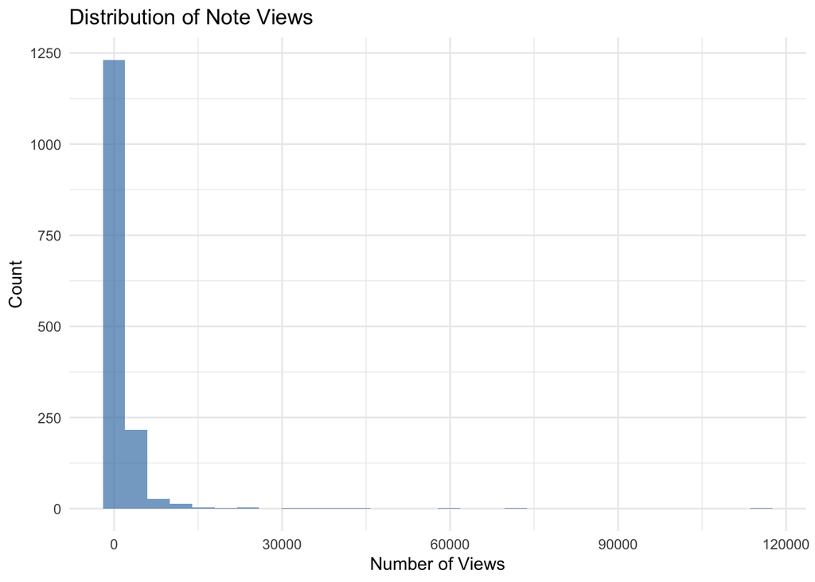

```r
# Visualize view distribution
ggplot(notes, aes(x = view)) +
  geom_histogram(fill = "steelblue", alpha = 0.7) +
  labs(title = "Distribution of Note Views",
       x = "Number of Views",
       y = "Count") +
  theme_minimal()
```

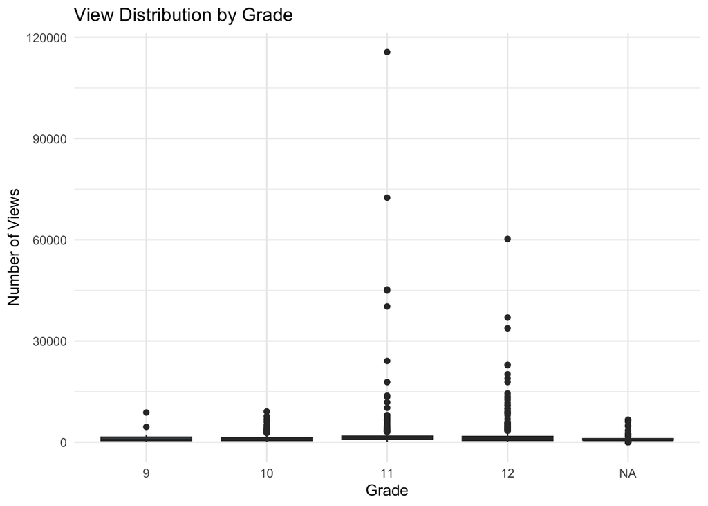

```r
# View distribution by grade
ggplot(notes, aes(x = as.factor(grade_id), y = view)) +
  geom_boxplot(fill = "lightblue") +
  labs(title = "View Distribution by Grade",
       x = "Grade",
       y = "Number of Views") +
  theme_minimal()
```

**Key Observations:** 1. The view distribution is heavily right-skewed 2. We may need to consider log transformation 3. Different grades show varying view patterns

# 4 Mutating Data

Let’s mutate some data types and data values to make it friendly for the analysis. Also, let’s replace any null values.

```r
# replacing the null cells
notes <- notes |>
  mutate(position = ifelse(is.na(position), "hidden", position),
         grade_id = ifelse(is.na(grade_id), 12, grade_id),
         subject_id = ifelse(is.na(subject_id), 1, subject_id),
  )

# mutating the types
notes <- notes |>
  mutate(
    title = nchar(title),
    user_id = as.factor(user_id),
    is_verified = as.factor(is_verified),
    status = factor(status,
                    levels = c("draft", "published"),
                    ordered = TRUE),
    subject_id = as.factor(subject_id),
    grade_id = as.factor(grade_id),
    position = factor(position,
                    levels = c("hidden", "shown"),
                    ordered = TRUE)
  )

colSums(is.na(notes))
```

```
      title        body     user_id        view is_verified      status
          0           0           0           0           0           0
 subject_id    grade_id    position
          0           0           0
```

# 5 Data Splitting & Pre-processing

Let’s split the data into training and test sets including 65% of records in the training set and stratifying the data by grade_id (because I’m interested to see which grade notes are getting more views.

```r
set.seed(427)

notes_split <- initial_split(notes, prop = 0.65, strata = grade_id)

notes_train <- training(notes_split)
notes_test  <- testing(notes_split)
```

## 5.1 Recipies

Linear model recipes:

```r
# Simple Mean and Mode Imputation
lm_recipe1 <- recipe(view ~ ., data = notes_train) |>
  # Mean (average) imputation for numeric features
  step_impute_mean(all_numeric_predictors()) |>
  # Mode (most repeated) imputation for categorical features
  step_impute_mode(all_nominal_predictors()) |>
  # Normalize numeric predictors
  step_normalize(all_numeric_predictors()) |>
  step_unknown(all_nominal(), -all_outcomes()) |>
  # Convert categorical variables to dummy variables
  step_dummy(all_nominal_predictors())

lm_recipe2 <- recipe(view ~ ., data = notes_train) |>
  # Median imputation
  step_impute_median(all_numeric_predictors()) |>
  # Lump rare categories into "Rare"
  step_other(all_nominal_predictors(), threshold = 0.05, other = "Rare") |>
  step_unknown(all_nominal(), -all_outcomes()) |>
  step_dummy(all_nominal(), -all_outcomes()) |>
  # Remove linear combinations of variables
  step_lincomb(all_predictors()) |>
  step_center(all_numeric_predictors()) |>
  # Standardize numeric variables
  step_scale(all_numeric_predictors())

# KNN Imputation
lm_recipe3 <- recipe(view ~ ., data = notes_train) |>
  step_nzv(all_predictors()) |>
  # KNN-based imputation
  step_impute_knn(all_numeric_predictors(), neighbors = 5) |>
  # Mode imputation for categorical features
  step_impute_mode(all_nominal_predictors()) |>
  step_unknown(all_nominal(), -all_outcomes()) |>
  # Convert categorical variables to dummy variables
  step_dummy(all_nominal_predictors()) |>
  # Remove collinear variables
  step_lincomb(all_predictors()) |>
  step_nzv(all_predictors()) |>
  step_normalize(all_numeric_predictors())
```

Knn model recipes:

```r
knn_recipe1 <- recipe(view ~ ., data = notes_train) |>
  step_impute_knn(all_numeric_predictors(), neighbors = 5) |>
  step_impute_mode(all_nominal_predictors()) |>
  step_normalize(all_numeric_predictors()) |>
  step_unknown(all_nominal(), -all_outcomes()) |>
  step_dummy(all_nominal_predictors())

knn_recipe2 <- recipe(view ~ ., data = notes_train) |>
  step_impute_median(all_numeric_predictors()) |>
  step_other(all_nominal_predictors(), threshold = 0.05, other = "Rare") |>
  step_scale(all_numeric_predictors()) |>
  step_unknown(all_nominal(), -all_outcomes()) |>
  step_dummy(all_nominal_predictors())


knn_recipe3 <- recipe(view ~ ., data = notes_train) |>
  step_nzv(all_predictors()) |>
  step_impute_mean(all_numeric_predictors()) |>
  step_unknown(all_nominal_predictors()) |>
  step_other(all_nominal_predictors(), threshold = 0.01, other = "Rare") |>
  step_dummy(all_nominal_predictors(), one_hot = TRUE) |>
  step_corr(all_numeric_predictors(), threshold = 0.75) |>
  step_lincomb(all_numeric_predictors()) |>
  step_normalize(all_numeric_predictors())
```

# 6 Model-Fitting & Evaluation

Lets create the `workflow_set` that contains 12 different workflows: 3 linear regression workflows, and 9 knn workflows.

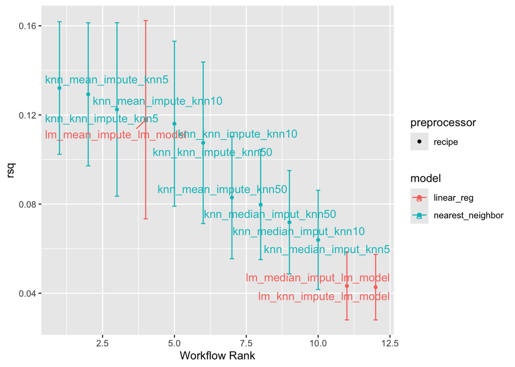

```r
lm_model <- linear_reg() |>
  set_engine('lm')

knn5_model <- nearest_neighbor(neighbors = 5) |>
  set_engine("kknn") |>
  set_mode("regression")
knn10_model <- nearest_neighbor(neighbors = 10) |>
  set_engine("kknn") |>
  set_mode("regression")
knn50_model <- nearest_neighbor(neighbors = 50) |>
  set_engine("kknn") |>
  set_mode("regression")

lm_models <- list(
  lm_model = lm_model
)
knn_models <- list(
  knn5 = knn5_model,
  knn10 = knn10_model,
  knn50 = knn50_model
)

lm_preprocessors <- list(
  lm_knn_impute = lm_recipe3,
  lm_mean_impute = lm_recipe1,
  lm_median_imput = lm_recipe2
)
knn_preprocessors <- list(
  knn_knn_impute = knn_recipe1,
  knn_mean_impute = knn_recipe3,
  knn_median_imput = knn_recipe2
)

knn_models <- workflow_set(knn_preprocessors, knn_models, cross = TRUE)
lm_models <-  workflow_set(lm_preprocessors, lm_models, cross = TRUE)

all_models <- lm_models |>
  bind_rows(knn_models)

notes_folds <- vfold_cv(notes_train, v = 5, repeats = 5)
notes_metrics <- metric_set(rmse, rsq)

all_fits <- all_models |>
  workflow_map("fit_resamples",
               resamples = notes_folds,
               metrics = notes_metrics)

autoplot(all_fits,  metric = "rsq") +
  geom_text_repel(aes(label = wflow_id))
```

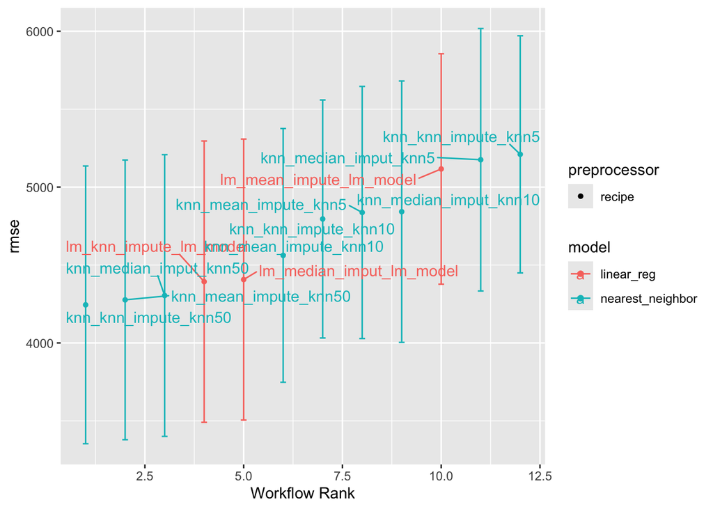

```r
autoplot(all_fits,  metric = "rmse") +
  geom_text_repel(aes(label = wflow_id))
```

Let’s re-fit the best model on the whole training set and estimate the error metrics on the test set.

```r
best_workflow <- workflow() |>
  add_recipe(knn_recipe1) |>
  add_model(knn50_model)

best_fit <- best_workflow |>
  fit(data = notes_train)

predictions <- predict(best_fit, new_data = notes_test)

results <- notes_test |>
  bind_cols(predictions)

metrics <- metric_set(rmse, rsq)
error_metrics <- results |>
  metrics(truth = view, estimate = .pred)

error_metrics
```

```
# A tibble: 2 × 3
  .metric .estimator .estimate
  <chr>   <chr>          <dbl>
1 rmse    standard    3940.
2 rsq     standard       0.209
```

# 7 Model Interpretation

Since KNN is a non-parametric model, we’ll use alternative approaches to understand feature relationships:

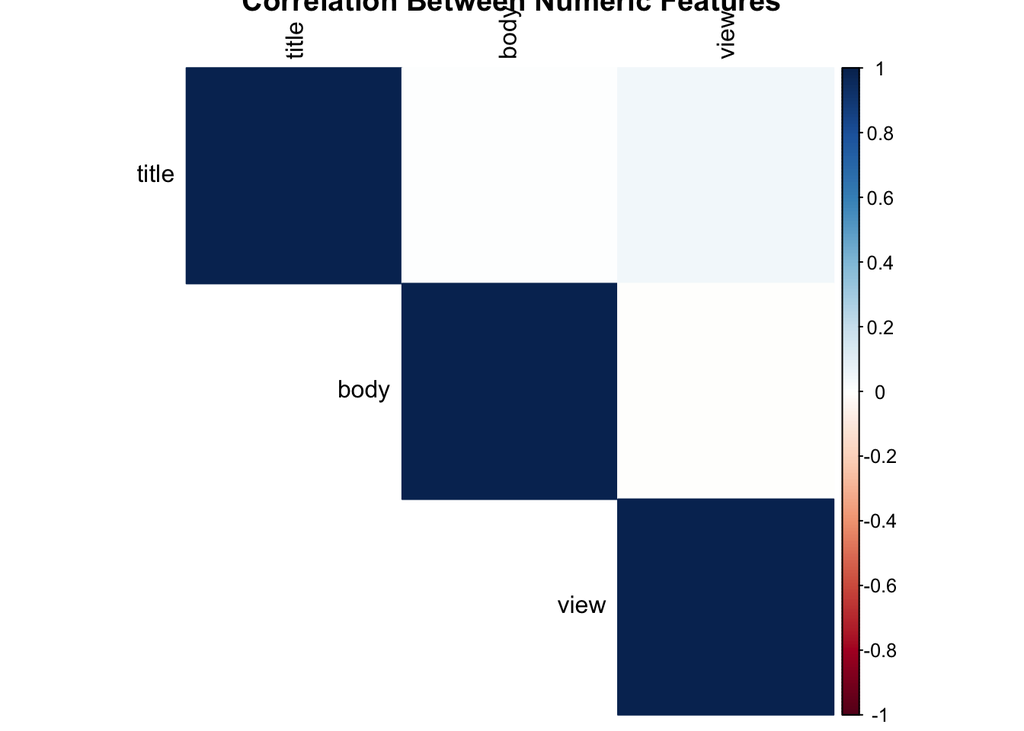

```r
# 1. Correlation analysis for numeric variables
numeric_vars <- notes_train %>%
  select_if(is.numeric)

cor_matrix <- cor(numeric_vars)
corrplot::corrplot(cor_matrix,
                  method = "color",
                  type = "upper",
                  tl.col = "black",
                  title = "Correlation Between Numeric Features")
```

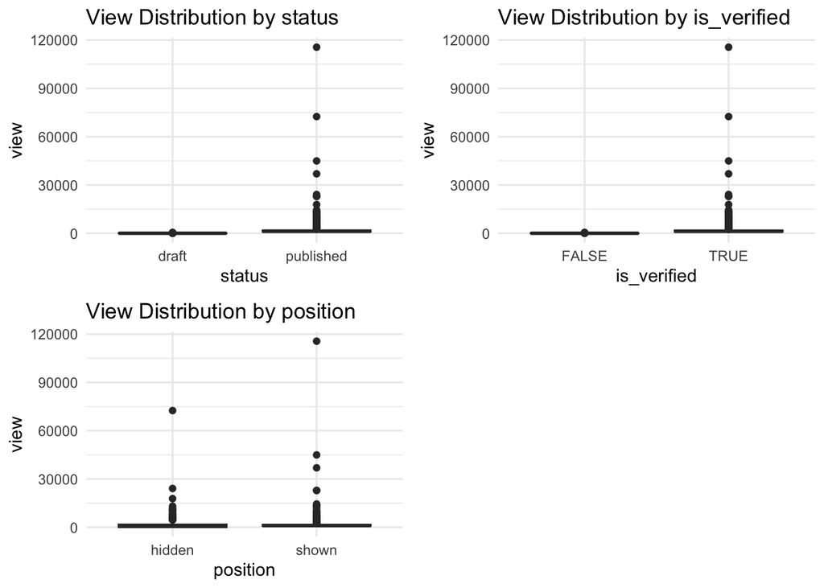

```r
# 2. Box plots for categorical variables
important_cats <- c("status", "is_verified", "position")
plots <- lapply(important_cats, function(var) {
  ggplot(notes_train, aes_string(x = var, y = "view")) +
    geom_boxplot(fill = "lightblue") +
    theme_minimal() +
    labs(title = paste("View Distribution by", var))
})

# Display plots in a grid
gridExtra::grid.arrange(grobs = plots, ncol = 2)
```

```r
# 3. Basic feature analysis
feature_summary <- notes_train %>%
  group_by(grade_id) %>%
  summarise(
    avg_views = mean(view),
    median_views = median(view),
    n_notes = n()
  ) %>%
  arrange(desc(avg_views))

knitr::kable(feature_summary,
             caption = "View Statistics by Grade Level",
             digits = 2)
```

View Statistics by Grade Level

| grade_id | avg_views | median_views | n_notes |
| --- | --- | --- | --- |
| 11 | 2203.22 | 1207 | 412 |
| 9 | 1812.83 | 931 | 12 |
| 12 | 1612.88 | 987 | 462 |
| 10 | 1204.21 | 944 | 91 |

**Key Findings:**

**Model Performance Analysis:**

1. The R-squared value of 0.21 suggests that about 21% of the variance in views is explained by our features.
2. Potential reasons for limited performance:
   1. Non-linear relationships not fully captured.
   2. Important external factors missing.
   3. High variance in view counts.

# 8 Limitations & Future Work

**Current Limitations:**

1. Limited feature set due to privacy constraints
2. External factors unknown

**Future Improvements:**

1. Include time-based features.
2. Collect content quality metrics.
3. Consider seasonal patterns

The best **rsq** that I obtained is 0.2085752 which is not super good. Selecting only specific variables/features can make the model better. If you provide me an interview opportunity, I will tell you how. :)